# Probabilidad y estadística

## Probabilidad

Ahora que hemos visto los diferentes escenarios bajo los cuales podemos observar datos que poseen incertidumbre, será necesario definir un encuadre que nos permita medir y cuantificar dicha incertidumbre. Sería ideal poder comenzar esta sección con una definición intuitiva y accesible de probabilidad. No obstante, definir este concepto puede ser más complicado de lo que parece a primera vista. Por ejemplo, podríamos comenzar diciendo que la probabilidad es un número que cuantifica la *factibilidad* de que ocurra un evento, cuando no se sabe a priori si este evento ocurrirá o no. Sin embargo, esta definición es circular, ya que utiliza el término *factibilidad* que refiere a la misma noción que probabilidad. No obstante, hay dos características importantes que vale la pena resaltar:

1. la probabilidad está asociada a un evento.
2. la probabilidad es un número.

A lo largo de la historia, se han usado diferentes definiciones para describir la noción de probabilidad:

##### Definición cláscia de probabilidad

La definición clásica postula que cuando todos los posibles resultados de un experimento son igualmente *factibles*, entonces la probabilidad de un evento es el cociente de los casos en los cuales el resultado es favorable entre el total de resultados posibles. Esta definición tiene dos desventajas:

1. Es circular en el sentido de que usa la noción de eventos **igualmente factibles**.
2. No toma en consideración eventos que no son igualmente factibles.

##### Definición frecuentista de probabilidad

La probabilidad de un evento está dada por la frecuencia relativa del evento sobre una larga repetición de experimentos. En otras palabras, la probabilidad de un evento es el límite del cosciente:

$$\frac{ \textrm{número de ocurrencias del evento}}{\textrm{total número de repeticiones del experimento}}$$

el cual converge cuando el número de experimentos tiende a infinito. Algunas de las desventajas de esta definición son:

1. Asume que eventos probabilísticos se pueden repetir una cantidad infinita de veces.
2. Es circular de alguna manera, pues descansa sobre la *ley de grandes números*.

##### Definición subjetiva de probabilidad

Esta definición sugiere que la probabilidad subjetiva de un evento es la propención de un individuo para tomar una apuesta sobre la ocurrencia de un evento. Las desventajas de esta definición son:

1. Diferentes individuos pondran diferentes precios a las loterias de los eventos.
2. Hay factores exógenos que pueden modificar los precios que cada individuo pone sobre las apuestas.

De lo anterior se desprende que hay serias limitantes para definir el concepto de probabilidad sin usar el rigor matemático. Por esto es necesario dar una definición formal de probabilidad y de los objetos a los cuales se les puede asociar. A continuación, definiremos qué es un evento, luego veremos que la probabilidad es una función que asocia un número a cada evento.

### Espacio muestral, punto muestral y eventos

Definiremos como espacio muestral al universo de todos los posibles resultados al realizar un experimento. Denotaremos al espacio muestral como $\Omega$. $\Omega$ debe cumplir las siguientes propiedades:

1. **Resultados excluyentes** solo una de las cosas dentro de $\Omega$ pueden ocurrir. Esto es si $\bar{w}\in\Omega$ sucede entonces $\{w\in\Omega:w\neq\bar{w}\}=\emptyset$.
2. **Resultados exhaustivos** al menos una de las cosas dentro de $\Omega$ deben suceder.
- $w\in\Omega$ se denomina punto muestral.
- $E\subset\Omega$ se denomina evento.

**Ejemplo**

Imaginemos que tiramos un dado. Solo existen seis posibles resultados para los números que pueden aparecer en la cara superior. En este caso el espacio muestral está dado por:

$$\Omega=\{1, 2, 3, 4, 5, 6\}$$
Cada uno de esos números representa un punto muestral. Los resultados son mutuamente excluyentes pues solo un número puede aparecer en la cara superior del dado. Los resultados también son exhaustivos pues al menos uno de los números aparecerá como resultado del experimmento. El evento:
$$E=\{1, 3, 5\}$$
Es un subconjunto de $\Omega$ y puede ser descrito como ‘un número impar aparece en la cara superior del dado’.

Notar que $\Omega \subset \Omega$ pues todo conjunto es un subconjunto de sí mismo y $\emptyset\subset\Omega$ pues esto es cierto para todo conjunto.

Definimos un espacio de eventos $\mathcal{F}$ como un conjunto de subconjuntos de $\Omega$. En otras palabras, todo elemento de $\mathcal{F}$ es un evento de $\Omega$.

### Definición de Probabilidad

Dado un espacio muestral $\Omega$. Denotamos por **P** a una función $P:\mathcal{F}\rightarrow[0,1]\subset\mathbb{R}$. Que asigna un número $P(E)$ a cada evento $E\in\mathcal{F}$. Luego entonces, **P** es una medida de probabilidad si y sólo si:

1. **Rango**

$$0\leq P(E)\leq 1\quad\forall E\in\mathcal{F}$$

2. **Evento seguro**
   $$P(\Omega)=1$$
3. **Aditividad**

$$P(\displaystyle\cup_{n=1}^\infty E_n)=\displaystyle\sum_{n=1}^\infty P(E_n)$$
para cualquier secuencia $\{E_1, E_2, \dots, E_n, \dots\}$ de eventos tal que $E_i\cap E_j = \emptyset\quad\forall i\neq j$.

Ejercicio 2.1

Supongamos que tiramos una moneda. Los posibles resultados son Águila o Sol (tails, heads):

$$\Omega=\{T, H\}$$

Consideramos el espacio de eventos como:

$$\mathcal{F}=\{\{T\}, \{H\}, \Omega, \emptyset\}$$
Prueba que la siguiente función define una medida de probabilidad

$$P(\Omega)=1, P(\emptyset)=0, P(\{T\})=\frac{1}{2}, P(\{H\})=\frac{1}{2}$$

De las definiciones anteriores se pueden derivar algunas propiedades de la función de probabilidad.

### Propiedades de la función de probabilidad

**Probabilidad del complemento**

Sea $E$ un evento y $E^c$ su complemento. Probar que

$$P(E^c) = 1 - P(E)$$

**Probabilidad de la unión**

Sean $E$ y $F$ dos eventos. Probar que

$$P(E\cup F) = P(E) + P(F) - P(E\cap F)$$

**Monotonicidad de la probabilidad**

Sean dos eventos $E$ y $F$ tal que $E\subset F$. Probar que

$$P(E) \leq P(F)$$

### Probabilidad condicional

Uno de los enclaves teóricos más relevantes de la teoría de probabilidad implica el estudio de cómo incorporar información nueva en nuestros supuestos probabilísticos. De modo un poco más formal, supongamos que tenemos un espacio muestral $\Omega$ y una medida de probabilidad $P$ sobre los conjuntos de $\Omega$. Ahora supongamos que sabemos que el resultado de un experimento pertenece a un conjunto $I\subset\Omega$. La pregunta que deseamos responder es cómo afecta este conocimiento al cálculo de las probabilidades del resto de los conjuntos de $\Omega$. Resulta que responder esta pregunta es más complicado de lo que uno pudiera pensar en primera instancia. Para simplificar la tarea, enunciaremos las propiedades que deseamos tener en la función de probabilidad condicional:

1. $P(E|I)$ debe ser una medida de probabilidad
2. $P(I|I) = 1$
3. Si $E\subset I^c$ entonces $P(E|I)=0$
4. Se debe mantener la proporcionalidad de las probabilidades, i.e. $\forall I, F, E\subset \Omega$ tenemos que:
   $$\frac{P(E|I)}{P(F|I)} = \frac{P(E)}{P(F)}$$
   Estas propiedades nos llevan a enunciar el siguiente resultado:

Siempre que $P(I) > 0$, $P(E|I)$ satisface las cuatro propiedades anteriores si y sólo si:

$$P(E|I) = \frac{P(E\cap I)}{P(I)}$$

### Eventos independientes

De la noción de probabilidad condicional podemos desprender la idea de independencia. Esto es, el conocimiento sobre la realización de un evento no nos arroja información adicional sobre la ocurrencia de algún otro. Esto sería equivalente a decir que existen dos eventos $E, F\subset \Omega$ tal que:
$$P(E|F) = P(E) \quad o \quad P(F|E) = P(F)$$
por lo anterior, diremos que dos eventos son independientes si y solo si:

$$P(E\cap F) = P(E)P(F)$$

### Bayes

Sean $A, B \subset \Omega$ tales que $P(A)P(B)\neq0$ recordando que por probabilidad condicional tenemos que

$$P(A|B) = \frac{P(A\cap B)}{P(B)}$$

y volviendo a aplicar probabilidad condicional

$$P(A|B) = \frac{P(B|A)P(A)}{P(B)}$$
Los componentes de esta ecuación suelen ser denominados de la siguiente manera:

1. $P(A)$ se llama el apriori.
2. $P(B|A)$ es la verosimilitud.
3. $P(B)$ es la probabilidad marginal o soporte.
4. $P(A|B)$ se conoce como la posterior.

### Números pseudoaleatorios

Una de las principales dificultades cuando intentamos abordar un encuadre probabilístico en un ambiente computacional es resolver el conflicto entre tener números lo suficientemente ‘aleatorios’ y la posibilidad de replicar experimentos. Dado que es imposible generar valores ‘100% aleatorios’ y al mismo tiempo replicar resultados, habrá que comprometerse con generadores de números que, durante largas corridas, dan la apariencia de ser aleatorios. A estos números los llamaremos **pseudoaleatorios**.

**Método multiplicativo congruencial**

Uno de los métodos más frecuentemente utilizados para generar números aleatorios comienza con un valor *semilla* $x_0$ y de manera recursiva genera una colección de valores $x_1, x_2, \dots, x_n$ siguiendo la siguiente relación:

$$x_n = ax_{n-1} \bmod m$$

En donde a y m son números enteros positivos. La operación módulo es el residuo de dividir $ax_{n-1}$ entre m. Por lo tanto, podrá tomar exclusivamente valores entre $0, 1, \dots, m-1$. El número $\frac{x_n}{m}$ se denomina pseudoaleatorio y es tomado como una aproximación a una variabla que se distribuye de manera uniforme en el intervalo $(0, 1)$.

En general, las constantes $a$ y $m$ deben seleccionarse de tal manera que cumplan con los siguientes criterios:

1. Para cualquier semilla inicial, la secuencia debe tener la ‘apariencia’ de ser una secuencia variables aleatorias uniformemente distribuidas en el intervalo $(0, 1)$.
2. Para cada semilla inicial, la secuencia de variables que puede ser generada antes de encontrar un ciclo debe ser larga.
3. Los valores deben ser computados de manera eficiente por una computadora.

Por lo regular, $m=2^{31−1}$ y $a=16807$ suelen dar buenos resultados. Una variante del método anterior es la siguiente:

$$x_n = (ax_{n−1} + c) \bmod m$$

A estos métodos se les llama generadores congruenciales mixtos dado que tienen términos aditivos y multiplicativos.

Ejercicio 2.2

Genera una gráfica con 1000 iteraciones del generador multiplicativo congruencial, usando los parámetros $a$ y $m$ que desees.

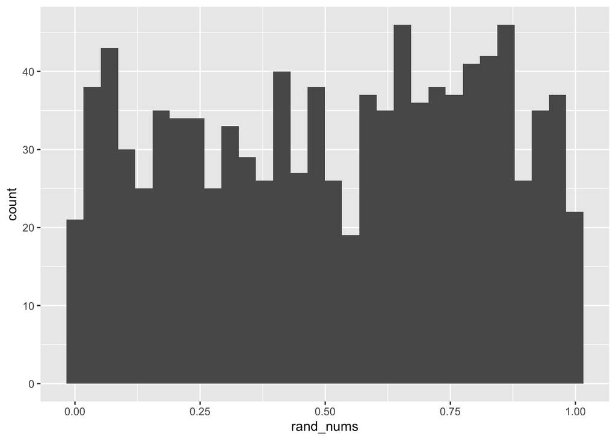

Si bien es suficiente tener un generador de números aleatorios uniformes para generar prácticamente todas las variables aleatorias de importancia, la teoría para justificar dichos métodos queda fuera del alcance de este curso. Por tanto, utilizaremos los métodos implementados en BaseR.

Antes de resolver los siguientes ejercicios, es bueno recordar los principios básicos de conteo:

**Ley del producto**

Si tenemos un experimento que consta de dos eventos $E_1, E_2$ subsecuentes, que pueden resultar en $n_1, n_2$ valores distintos. Entonces el número de posibles resultados del experimento está dado por:

$$n=n_1\times n_2$$

**Permutación**

Cualquier secuencia **ordenada** de $k$ objetos tomados sin reemplazo de un conjunto de $n$ objetos distintos se denomina una permutación de tamaño $k$. El número de permutaciones distintas está dado por

$$P^n_k=\frac{n!}{(n-k)!}$$

**Combinación**

Cualquier secuencia **independiente de orden** de $k$ objetos tomados sin reemplazo de un conjunto de $n$ objetos distintos se denomina una combinación de tamaño $k$. El número de combinaciones distintas está dado por

$$C^n_k=\frac{n!}{(n-k)!k!}$$

Ejercicio 2.3

1. Determina la probabilidad de que al menos dos personas en un elevador de 10 personas cumplan años el mismo día.
2. Genera una gráfica de número de personas vs probabilidad de que al menos dos de ellas cumplan años el mismo día.

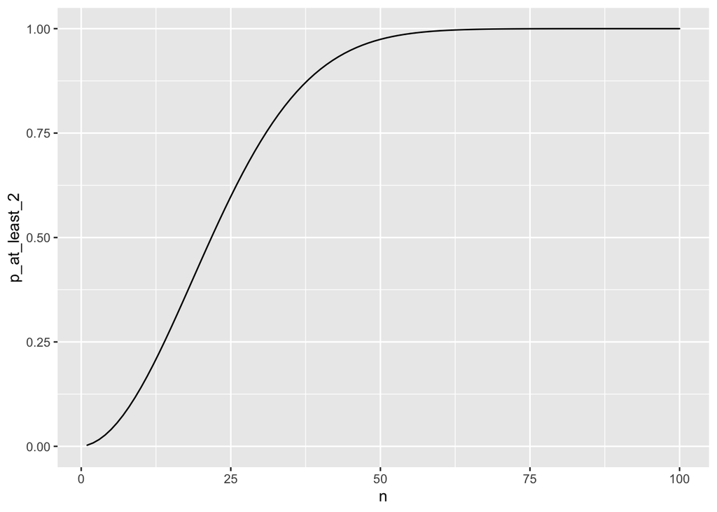

Ejercicio 2.4

1. Imaginen una enfermedad que se presenta en 1 de cada 100,000 individuos. Existe una prueba que identifica correctamente a un individuo como enfermo 99% de las veces. Mientras que identifica a un individuo erroneamente como enfermo 2% de las veces. Si se toma un individuo aleatoriamente y la prueba lo identifica como enfermo ¿Cuál es la probabilidad de que tenga la enfermedad?
2. Supongamos que con tal de quitarse de dudas, el individuo realiza la prueba una segunda vez. Si la nueva prueba lo identifica como enfermo ¿Cuál es la probabilidad de que tenga la enfermedad?
3. Grafica la probabilidad de tener la enfermedad vs número de pruebas cuando la enfermedad ocurre en 1 de cada 1,000,000 de personas.

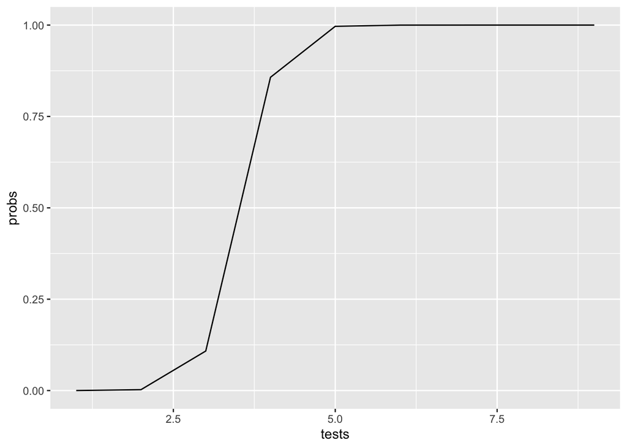

Ahora que hemos visto la teoría detrás de la cuantificación de la incertidumbre, ha llegado el momento de definir teóricamente una variable aleatoria junto con los elementos mas importantes asociados a su función de distribución de probabilidad.

### Variables aleatorias

Cómo hemos visto antes, todo experimento en donde está involucrada la incertidumbre nos exige la integración de conceptos formales de probabilidad en nuestro aservo de herramientas. Ahora bien, ha llegado el momento de definir formalmente el concepto de variable aleatoria.

**Variable aleatoria**

Definimos como variable aleatoria a ‘todo’ mapeo entre un espacio muestral $\Omega$ y los números reales.

$$X; \forall E \subset \Omega => X(E) \in \mathbb{R}$$

**Ejemplos**

1. El resultado de tirar un dado.
2. La suma de las caras de un dado.
3. Atinar a seis números consecutivos en la lotería.

Ahora, podemos asignar una medida de probabilidad a cada posible resultado en el experimento. Definimos la probabilidad del evento $P(X=x_i)$ (que la variable aleatoria tome un valor específico). Como $P({s_j\subset \Omega| X(s_j)=x_i})$.

**Distribución de probabilidad**

Definiremos a la función de distribución de probabilidad asociada a la variable aleatoria $X$ cómo:

$F_X(x) = P(X\leq x)$

Ejercicio 2.5

Describe de manera analítica la función de distribución de probabilidad de la variable aleatoria: X=número de resultados pares en tres tiros de un dado justo.

Una función de distribución $F_X$ será tal, si y sólo si las siguientes condiciones se cumplen:

1. $\displaystyle\lim_{x\rightarrow-\infty}F_X(x)=0$ y $\displaystyle\lim_{x\rightarrow\infty}F_X(x)=1$
2. $\forall x_1, x_2 \in \mathbb{R}; x_1\leq x_2\Rightarrow F_X(x_1)\leq F_X(x_2)$
3. $\displaystyle\lim_{x\downarrow x_0}F_X(x)=F_X(x_0)$

Ejercicio 2.6

Sea $X$ el número de *heads* en una serie de tiros de moneda antes de obtener *tails*. Encuentra la función de distribución de probabilidad $F_X$ de $X$.

$$P(X=x)=(1-p)^xp$$

Exploremos visualmente esta distribución en R.

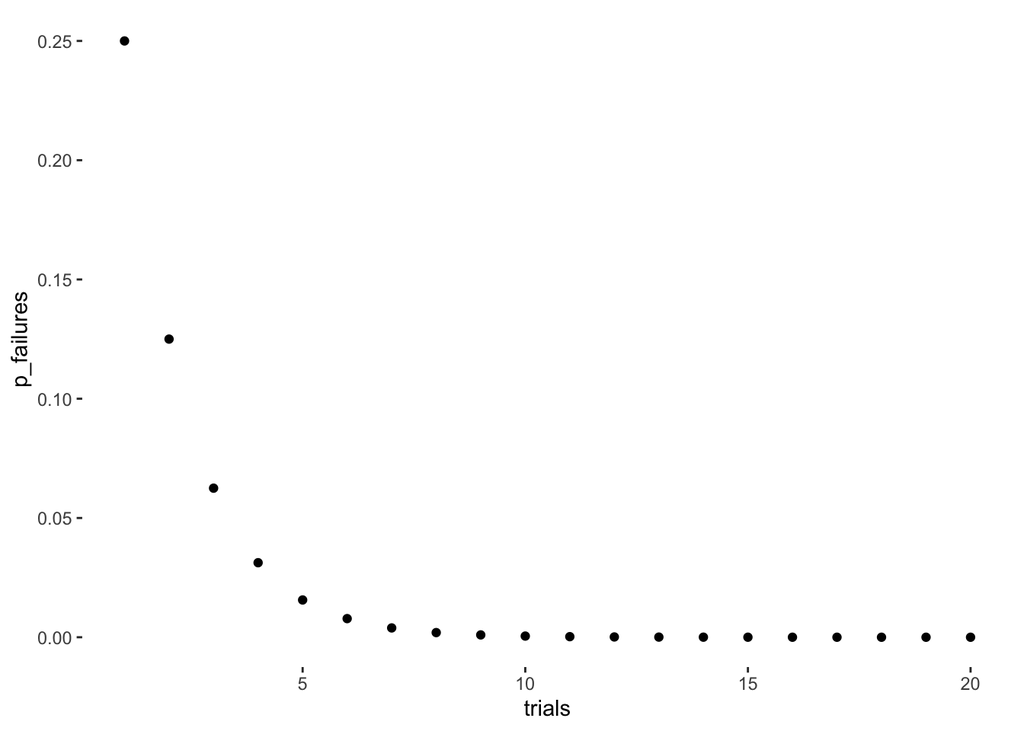

La función de distribución de probabilidad

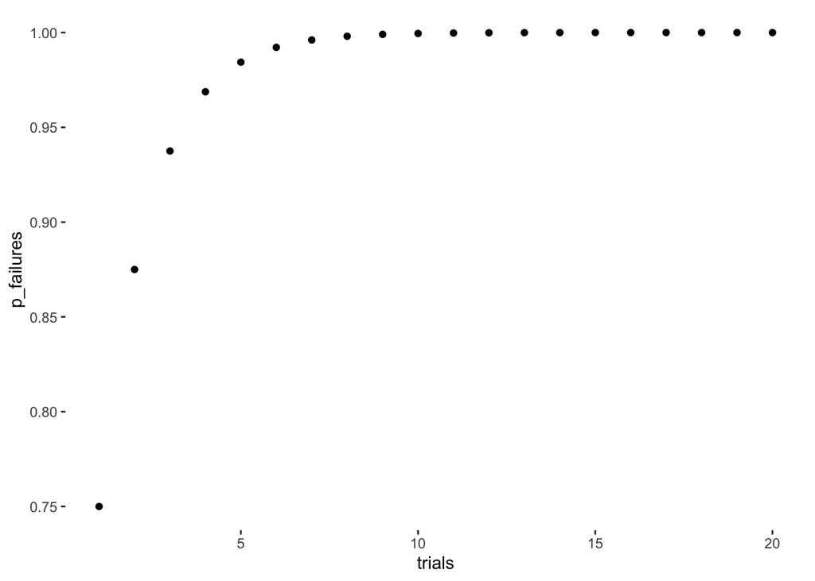

```
## [1] 0.0009765625
```

Esta probabilidad tan baja nos da evidencia en contra de que nuestra moneda sea justa. Tomaremos esta noción más adelante cunado definamos pruebas de hipótesis.

Ahora estamos en posición de caracterizar de manera formal las variables en discreta y continua.

#### Tipos de distribuciones

Una variable aleatoria $X$ es continua si su función de distribución $F_X$ es continua, por otra parte, una variable aleatoria es discreta si su función de distribución es escalonada.

Nota: Decimos que dos variables aleatorias $X$, $Y$ son identicamente distribuidas si $F_X(x)=F_y(x) \forall x\in \mathbb{R}$

En el caso de variables discretas, definimos a la función de masa de probabilidad como $f_X(x)=P(X=x)$, notar que esto implica $F_X(x)=\displaystyle\sum_{x_i\leq x}^x P(X=x_i)$. Mientras que en el caso de variables continuas, tenemos que $F_X(x)=\displaystyle\int_{-\infty}^xf_X(t)dt$ en donde $f_X$ es la función de densidad de probabilidad.

#### Valor esperado

El valor esperado de una variable aleatoria $g(X)$ se define como:

$$E\big[g(x)\big]= \left\{
\begin{array}{ll}
\int_{-\infty}^{\infty}g(t)f_X(t)dt & X\in\mathbb{R} \\
\sum_{x\in X}g(t)f_X(t) & X\in\mathbb{Z} \\
\end{array}
\right.$$

podemos ver que la esperanza no corresponde a otra cosa más que al concepto intuitivo de ‘ponderar’ los valores del soporte de $X$, esto es $x_i\in\mathbb{R}|f_X(xi)>0$, con respecto a la probabilidad que tienen de ocurrir.

#### Momentos

Dada una variable aleatoria $X$ para cada entero $n$, el *n-ésimo* momento está dado por:

$$\mu_n'=E\big[X^n\big]$$
y el *n-ésimo* momento central por:
$$\mu_n=E\big[(X-\mu)^n]$$
En donde $\mu=\mu'=E\big[X\big]$.

Notar en particular que la varianza es el segundo momento central.

#### Distribuciones discretas

##### Distribución Bernoulli

Está distribución, nombrada en honor a Jacob Bernoulli, se emplea cuando la variable aleatoria medida en un experimento tiene exactamente dos resultados posibles. Comúnmente, etiquetamos estos resultados como “éxito” y como “fracaso”. También podemos denotar un éxito por 1 y un fracaso por 0.

$X$ es una variable aleatoria Bernoulli cuando $X$ puede tomar el valor de “éxito” (**1**) cuya probabilidad está dada por $p$ y, complementariamente, el valor de “falla” (**$0$**) con probabilidad dada por $q = 1 - p$. Adicional, su media y desviación estándar toman los siguientes valores:

$$\mu = p \quad\quad \sigma = \sqrt{p(1-p)}$$

La forma analítica de la función de masa de probabilidad de una variable aleatoria $X\sim \operatorname {Bernoulli} (p)$, es la siguiente:

$$P[X = x] = \begin{cases} 1-p & \text{si $x=0$}\\ p & \text{si $x=1$} \end{cases}$$

En tanto que la función de distribución acumulada de la variable aleatoria $X\sim \operatorname {Bernoulli} (p)$ se expresa de la siguiente forma:

$$F(x) = \begin{cases} 0 & x<0\\ 1- p & 0 \leq x < 1 \\ 1 & x \geq 1 \end{cases}$$

###### Distribución Binomial

La distribución binomial suele emplearse para describir la probabilidad de tener exactamente $k$ éxitos en $n$ ensayos Bernoulli, independientes, y con probabilidad de éxito $p$. Podríamos identificar la probabilidad final como

(# de escenarios) × $P$ (escenario único)

Si se considera $P$ (escenario único) en el caso general de $k$ éxitos y $n - k$ fracasos en los $n$ ensayos, en cualquiera de estos escenarios, aplicamos la regla de multiplicación para eventos independientes (fórmula general):

$$p^{k}(1-p)^{n-k}$$

Ahora, presentamos una fórmula general para el número de formas de elegir $k$ éxitos en $n$ ensayos, i.e., organizar $k$ éxitos y $n - k$ fracasos:

$$\binom{n}{k} = \frac{n!}{k!(n-k)!}$$

De esa forma, para una distribución binomial, suponiendo que la probabilidad de que una sola prueba sea exitosa es $p$, entonces, la probabilidad de observar exactamente $k$ éxitos en $n$ ensayos independientes está dada por

$$\binom{n}{k}p^{k}(1-p)^{n-k} = \frac{n!}{k!(n-k)!} p^{k}(1-p)^{n-k}$$

En tanto que la media, la varianza y la desviación estándar del número de éxitos observados se calculan de la siguiente manera:

$$\mu = np \quad \quad \sigma ^{2} = np(1-p) \quad \quad \sigma = \sqrt{np(1-p)}$$

Para que una variable aleatoria discreta se distribuya de manera binomial, se deben cumplir las siguientes 4 condiciones:

1. Los experimentos son independientes.
2. El número de ensayos, $n$, es fijo.
3. El resultado de cada experimento puede clasificarse como éxito o fracaso.
4. La probabilidad de éxito, $p$, es la misma para cada experimento.

El primer paso para usar el modelo binomial es verificar que el modelo sea apropiado. El segundo paso es identificar $n$, $p$ y $k$. El último paso es aplicar las fórmulas e interpretar los resultados.

Exploremos las funciones `pbinom`, `rbinom`, `dbinom`en R.

Ejercicio 2.6

Genera 100 experimentos en donde deseas calcular el número de éxitos en 10 volados. Gráfica la distribución de resultados para distintos valores de $p={.1, .2, .3, ...,.9}$

###### Distribución Geométrica

Pensemos en preguntas tales como ¿cuántas repeticiones en el lanzamiento de una moneda se deben realizar hasta obtener cara?; ¿cuántas veces se debe lanzar un dado hasta obtener un 4? En general, para calcular el número promedio (esperado) de repeticiones necesarias para obtener el primer éxito, o resultado determinado, empleamos la distribución geométrica.

En otras palabras, la distribución geométrica describe el tiempo de espera hasta el éxito de las variables aleatorias Bernoulli **independientes e idénticamente distribuidas** (iid). Este aspecto de independencia refiere a que las repeticiones o individuos observados no se afectan entre sí; en tanto que la identidad significa que cada repetición o individuo observado tiene la misma probabilidad de éxito.

Si la probabilidad de éxito en una observación es $p$ y la probabilidad de fracaso es $1 - p$, entonces la probabilidad de encontrar el primer éxito en la $n-esima$ observación está dada por:

$$(1-p) ^{n-1} p$$

A su vez, la media (que resulta ser igual al valor esperado), la varianza y la desviación estándar de este tiempo de espera están dadas, respectivamente, de la siguiente manera:

$$\mu = \frac{1}{p} \quad \quad \sigma ^{2} = \frac{1-p}{p^{2}} \quad \quad \sigma = \sqrt{\frac{1-p}{p^{2}}}$$

De acuerdo a lo anterior, en promedio, se necesitan $1 / p$ intentos para tener éxito. Este resultado matemático es consistente con lo que debiera resultar intuitivo; i.e., si la probabilidad de éxito es alta, no tendríamos que esperar mucho para tener éxito. De forma inversa, si la probabilidad de éxito es baja, esperaríamos muchas observaciones o repeticiones antes del primer éxito.

Finalmente, se debe resaltar la importancia del supuesto de independencia. Gracias a él, matemáticamente, se construye la probabilidad de éxito en la $n-esima$ prueba, haciendo uso de la regla de multiplicación para procesos independientes. Por ello, no resulta sencillo generalizar el modelo geométrico para ensayos dependientes.

Exploremos las funciones `pgeom`, `rgeom`, `dgeom`en R.

#### Distribuciones continuas

###### Distribución Exponencial

Es la distribución de probabilidad que modela el tiempo entre eventos en un proceso en el que los eventos ocurren de manera continua e independiente a una tasa promedio constante (proceso Poisson). Es el análogo continuo de la distribución geométrica.

Esta distribución suele ser importante tanto en teoría de colas como en problemas de confiabilidad. El tiempo entre las llegadas en las instalaciones de servicio y el tiempo de falla de los componentes y sistemas eléctricos, frecuentemente involucran la distribución exponencial.

El parámetro de esta distribución es $\lambda$ (lambda) el cual representa el número promedio de eventos esperados por unidad de tiempo; también se le conoce como “la tasa de ocurrencia” del fenómeno que se observa, la cual, como ya se mencionó, se mantiene constante debido a la propiedad de esta distribución de pérdida de memoria.

Formalmente, una variable aleatoria continua $X$ tendrá una distribución exponencial con parámetro $\lambda > 0$ — i.e. $X \backsim Exp(\lambda)$) — si su función de densidad es

$$f_{X}(x) = \lambda e^{-\lambda x}$$

La media de $X$ se expresa mediante

$$E[X] = \frac{1}{\lambda}$$

Y la varianza de $X$ está definida por

$$Var(X) = \frac{1} {{\lambda}^{2}}$$

Algunas aplicaciones comunes importantes de esta distribución, además de las ya mencionadas, son el tiempo que esperan los clientes en fila antes de recibir servicio, modelos de riesgo de crédito (tiempo de declaratoria de impago), entre otras tantas.

###### Distribución Normal

La distribución normal es la más importante en el campo de probabilidad y estadística, además de ser la que, por mucho, aparece más comúnmente en la realidad cotidiana. El comportamiento de diversas variables suele ser bien representado por esta distribución; por ejemplo, características físicas de las personas ( altura o peso), puntajes en un examen, indicadores económicos, etc.

Se dice que una variable aleatoria continua *X* tiene una **distribución normal** con parámetros $\mu$ y $\sigma$, donde $- \infty < \mu < \infty$ y $\sigma > 0$ si la función de densidad de probabilidad de *X* es

$$f(x; \mu, \sigma) = \frac{1}{ \sqrt{2 \pi} \sigma} e^{(x-\mu)^{2}/(2\sigma^{2})}$$

La representación gráfica de la distribución normal es una curva simétrica (con respecto a $\mu$), unimodal y en forma de campana, conocida como curva o campana de Gauss. La ubicación y forma de dicha curva será determinada por los parámetros de la media ($\mu$) y la desviación estándar ($\sigma$).

El valor de la media desplazará el centro de la curva hacia la izquierda o hacia la derecha, mientras que el valor de la desviación estándar hará que ésta se “estire” o se “comprima” (entre mayor sea $\sigma$, más comprimida o densa será la curva).

Gráficamente, $\mu$ representa el centro y punto más alto de la curva, al tiempo que es tanto la media como la mediana de la distribución; mientras que $\sigma$ representa la distancia entre $\mu$ y el punto de inflexión de la curva.

Los momentos centrales de la distribución normal son, entonces, la media $\mu$ que indica la tendencia central de la distribución (primer momento) y la varianza $\sigma ^{2}$ que indica el ancho o la desviación de la distribución (segundo momento).

Existe un caso especial de la normal: la **función de distribución normal estándar**, en donde $\mu = 0$ y $\sigma =1$. Asimismo, es posible transformar cualquier variable aleatoria $X$, cuya distribución sea normal, en una variable aleatoria normal estándar $Z$, mediante un proceso de **normalización** o **estandarización**, de la siguiente manera:

Si $X \sim N(\mu, \sigma ^{2})$, entonces
$$Z = \frac{X- \mu }{ \sigma }$$

es una variable aleatoria normal estándar
$$Z \sim N(0, 1)$$

Finalmente, la suma de $n$ variables aleatorias normales independientes resulta en una variable aleatoria normal, cuya media es la suma de medias, y la varianza es la suma de varianzas. De forma que si

$$X_{i} \sim N( \mu _{i}, \sigma _{i}), i=1,2, ...,n$$
entonces
$$Y= X_{1} + X_{2} + ... + X_{n} \sim N( \mu _{1} + \mu _{2} + ... + \mu _{n}, \sqrt{ \sigma ^{2}_{1} + \sigma ^{2}_{2} + ... + \sigma ^{2}_{n} })$$

Exploremos las funciones `pnorm`, `rnorm`, `dnorm`en R.

##### Distribución *t* de Studen

Esta distribución es comúnmente útil cuando se intentan realizar cálculos de inferencia o estimación de media y el tamaño de muestra para calcular el error estándar es pequeño — lo cual no significa que sólo sea útil con muestras pequeñas.

La forma gráfica de esta distribución es una campana, muy similar a la de la distribución Normal, pero las colas de la *t* de Student son más amplias, lo cual se traduce en que eixiste una mayor probabilidad de que las observaciones se ubiquen más allá de dos desviaciones estándar de la media, en comparación con la distribución normal.

La curva siempre se centra en 0 y su forma variará debido a un único parámetro de la distribución: **grados de libertad**. Cuanto mayores sean los grados de libertad, más se aproximará la distribución *t* a la distribución normal estándar. De hecho, por arriba de 30 grados, ambas distribuciones se vuelven casi indistinguibles la una de la otra. Por último, estos grados de libertad suelen relacionarse con el tamaño de la muestra.

Ahora bien, pasemos a definir la forma funcional: Si $X$ es una variable aleatoria continua con distribución $t$, y $k>0$ son los grados de libertad, entonces $X\backsim t_{k}$ y su función de densidad es la siguiente:

$$f_{X}(x) =\frac{\Gamma(\frac{k+1}{2})}{\Gamma(\frac{k}{2})\sqrt{k\pi}}(1 +\frac{x^{2}}{k})^{-\frac{k+1}{2}}$$

para $x\in \mathbb {R}$, y en donde $\Gamma$ es la función gamma.

De igual forma, la media de $X$ cuando $k>1$ es

$$E[X]=0$$

La varianza de $X$ cuando $k>2$ es

$$Var(X) = \frac{k}{k-2}$$

Y, finalmente, la curtosis de $X$ cuando $k>4$ es

$$Curt(X) = \frac{6}{k-4}$$

En general, se recomienda utilizar la distribución *t* para la inferencia de la media muestral cuando las observaciones son independientes y casi normales. Al examinar la media muestral y el error estándar estimado de una muestra de $n$ observaciones independientes y casi normales, usamos una distribución *t* con $n - 1$ grados de libertad.

Asimismo, se emplea en pruebas *t* de Student — para rechazar o no una hipótesis—, ya sea en una sola muestra, para probar que la media de la población es igual al valor $\mu_{0}$; en dicho caso, se utiliza el siguiente estadístico:

$$t = \frac{\bar{x}-\mu_{0}}{s/\sqrt{n}}$$

en donde $\bar{x}$: promedio muestral, $s$: desviación estándar muestral, $n$: tamaño de muestra.

O bien, en una prueba de dos muestras indepndientes, para determinar si existe una diferencia significativa entre las medias de ambos grupos, y en donde se emplea el estadístico

$$t= \frac{\bar{X_{1}}- \bar{X_{2}}}{S_{X_{1}X_{2}}\sqrt{\frac{2}{n}}}$$

en donde se asumen tamaños de muestra ($n$) y varianzas iguales en ambos grupos, $\bar{X_{i}}$ es el promedio muestral del grupo $i$, y $S_{X_{1}X_{2}}$ es el estimador de la desviación estándar común de ambas muestras.

###### Distribución Pareto

Distribución de probabilidad que se utiliza en la descripción de fenómenos sociales, de control de calidad (tiempo de vida útil de un artículo manufacturado), científicos, entre otros tipos de fenómenos observables. Fue aplicado originalmente para describir la distribución de la riqueza en una sociedad.

El principio de Pareto o regla “80-20” establece que el 80% de los resultados se deben al 20% de las causas. Las observaciones empíricas demuestran que esa distribución 80-20 se ajusta a una amplia gama de casos como los fenómenos naturales o las actividades humanas.

Gráficamente, la distribución Pareto está sesgada con colas que decaen lentamente; i.e., gran parte de los datos se encuentran en las colas. Tiene dos parámetros que la definen: $\alpha$ (parámetro de forma, de pendiente o índice de Pareto) y $x$ (parámetro de ubicación).

Formalmente, si $X$ es una variable aleatoria continua que se distribuye Pareto, con $\alpha >0$ y $x_{i} > 0$ entonces $X \backsim Pareto(\alpha,x_{i})$, y la función de densidad de $X$ se define de la siguiente manera:

$$f_{X}(x) =\frac{\alpha x_{i}^{\alpha}}{x^{\alpha+1}}$$
cuando $x_{i} \leq x$.

La media de $X$ se expresa mediante

$$E[X] = \frac{\alpha x_{i}}{\alpha-1}$$
con $\alpha > 1$.

Y la varianza de $X$ está definida por

$$Var(X) = \frac{\alpha x_{i}^{2}}{(\alpha-1)^{2}(\alpha-2)}$$
con $\alpha > 2$.

### Teoremas de límite

Volvamos al encuadre inicial, en dónde veíamos diferentes fenómenos representados en datos como una muestra aleatoria proveniente de una distribución poblacional desconocida. Como hemos visto, hay una gran cantidad de parámetros que determinan la posición y forma de nuestras distribuciones. Sería muy conveniente poder estimar dichos parámetros a partir de nuestra muestra. Para esto, definiremos el concepto de estadístico $T$. Un estadístico es una función que mapea los valores de una muestra en números reales. Por supuesto, nosotros quisieramos tener estadísticos que absorban toda la información de la muestra (principio de suficiencia) sin desperdiciar información.

**Estadísticos suficientes**

Dada una función de densidad o masa de probabilidad $f_X(x|\theta)$ de una muestra $X$. Un estadístico $T(X)$ es suficiente para $\theta$ si y solo si, existen funciones $g(t|\theta)$ y $h(x)$ tal que para todos los puntos $x$ se tiene que:

$$f(x|\theta) = g(T(x)|\theta)h(x)$$

**Resultado importante**

Si $X=\{x_1, x_2, \dots, x_n\}\overset{iid}{\sim} N(\mu, \sigma^2)$ entonces $\bar{x}=\frac{1}{n}\displaystyle\sum_{i=1}^nx_i$ y $\bar{\sigma}^2=\frac{1}{(n-1)}\displaystyle\sum_{i=1}^n(x_i-\bar{x})^2$ son estadísticos suficientes para $\mu$ y $\sigma^2$. Estas además resultan ser mínimos (cualquier otro estadístico suficiente será una función de estos).

Existen múltiples métodos para estimar parámetros poblacionales de manera puntual: ‘Método de momentos’, ‘Máxima verosimilitud’. En este curso enunciaremos formalmente el último y veremos algunos ejemplos.

**Maxima verosimilitud**

Si $X=\{x_1, x_2, \dots, x_n\} \overset{iid}{\sim} f(x|\theta_1, \theta_2, \dots, \theta_k)$ entonces definiremos la función de verosimilitud como:

$$L(\theta_1, \theta_2, \dots, \theta_k |x_1, x_2, \dots, x_n)=\displaystyle\prod_{i=1}^nf(x_i|\theta_1, \theta_2, \dots, \theta_k)$$
Ejercicio 2.7.a

Dada una muestra $X=\{x_1, x_2, \dots, x_n\}\overset{iid}{\sim} Bernoullie(p)$. Obtén el estimador de máxima verosimilitud para $p$. Recuerda que $x\sim Bernoullie(p)$ si y solo si $f_X(x)=p^x(1-p)^{1-x}\mathbb{I}_{0,1}$

Ejercicio 2.7.b

Dada una muestra $X=\{x_1, x_2, \dots, x_n\}\overset{iid}{\sim} Geom(p)$. Obtén el estimador de máxima verosimilitud para $p$. Recuerda que $x\sim Geom(p)$ si y solo si $f_X(x)=p(1-p)^{x-1}$

Ejercicio 2.7.c

Dada una muestra $X=\{x_1, x_2, \dots, x_n\}\overset{iid}{\sim} Exp(\lambda)$. Obtén el estimador de máxima verosimilitud para $\lambda$. Recuerda que $x\sim Exp(\lambda)$ si y solo si $f_X(x)=\lambda e^{-\lambda x}$

Ejercicio 2.7.d

Dada una muestra $X=\{x_1, x_2, \dots, x_n\}\overset{iid}{\sim} N(\mu, 1)$. Obtén el estimador de máxima verosimilitud para $\mu$. Recuerda que $x\sim N(\mu, \sigma^2)$ si y solo si $f_X(x)=\frac{1}{\sqrt{2\pi\sigma^2}}e^{\frac{(x-\mu)^2}{2\sigma}}$

Los estimadores de máxima verosimilitud tienen varias propiedades deseables:

1.- Insesgados
$$E(\hat{\theta}) = \theta$$
2.- Eficientes El estimador alcanza la mínima varianza posible (igualdad con la cota de Cramer y Rao) 3.- Consistentes
$$P(|\hat{\theta}-\theta| > \epsilon) \rightarrow 0; n \rightarrow \infty$$
4.- Normalidad asintótica
$$\sqrt{n}(\hat{\theta}-\theta)\overset{d}{\sim}N(0,\frac{1}{I(\theta)})$$

Cómo hemos visto, la media muestral es un estimador de estimador de máxima verosimilitud para el parámetro de localización en una gran cantidad de distribuciones. Sería ideal contar con un método que nos permita determinar la precisión de este estimador de manera eficiente dada una muestra. El siguiente resultado nos brinda una solución fundamental a este problema.

**Ley de los grandes números**

Dada una muestra $X=\{x_1, x_2, \dots, x_n\} \overset{iid}{\sim} f(x|\theta_1, \theta_2, \dots, \theta_k)$ tal que $E(X_i)=\mu$ y $Var(X_i)=\sigma^2>0$. Si definimos $\bar{X}_n = \frac{1}{n}\displaystyle\sum_{i=1}^nX_i$. Entonces:

$\forall\epsilon>0$

$P(\displaystyle\lim_{n\rightarrow\infty}|\bar{X}_n-\mu|<\epsilon)=1$

Como nota adicional, en el caso del estimador de la varianza tenemos:

$\displaystyle\lim_{n\rightarrow\infty}P(|\bar{\sigma}^2_n-\sigma^2|\geq\epsilon)=\frac{var(\bar{\sigma})}{\epsilon^2}$

Notar que $var(\bar{\sigma})\rightarrow0$ cuando $n\rightarrow 0$.

**Teorema central de límite**

Sea $X=\{x_1, x_2, \dots, x_n\} \overset{iid}{\sim} f(x|\theta_1, \theta_2, \dots, \theta_k)$ tal que $E(X_i)=\mu$ y $Var(X_i)=\sigma^2>0$. Si definimos a $\bar{X}=\frac{1}{n}\displaystyle\sum_{i=1}^nX_i$. Entonces, $\forall x\in\mathbb{R}$

$$\displaystyle\lim_{n\rightarrow\infty}\sqrt{n}\Big(\frac{\bar{X}_n-\mu}{\sigma}\Big)\rightarrow\displaystyle\int_{-\infty}^{x}\frac{1}{\sqrt{2\pi}}e^{\frac{y^2}{2}}dy$$
Como veremos a continuación, estos resultados serán de fundamental importancia para poder llevar a cabo inferencia estadística. Además de tener una gran variedad de aplicaciones prácticas en otros campos. Veamos un ejemplo.

**Evaluación de integrales**

Sea $g:[0-1] -> R$ una función integrable. Supongamos que queremos calcular $\theta=\displaystyle\int_0^1g(t)dt$ Es fácil notar que si $U\sim Unif(0,1)$ entonces $\theta=E[g(U)]$. Por lo tanto, si $U_1, U_2, \dots, U_n$ son variables aleatorias uniformes independientes. Entonces $g(U_1), g(U_2), \dots, g(U_n)$ son independientes idénticamente distribuidas y con probabilidad 1 tendremos que:

$$\displaystyle\lim_{n\rightarrow\infty}\displaystyle\sum_{i=1}^n\frac{g(U_i)}{n}\rightarrow E[g(U)] = \theta$$
Ejercicio 2.8

Obten el valor de:

$$\displaystyle\int_{0}^1 x^2\sin(x)\sqrt{x+e^x}$$

```r
int <- map_dbl(runif(10000), ~.**2*sin(.)*sqrt(.+exp(.)))
mean(int)
```

```
## [1] 0.3877708
```

## Inferencia

Es momento de recordar el planteamiento incial que nos ha traido aquí. Los fenómenos de la naturaleza que deseamos estudiar, en su mayoría, se encuentran cuantificados en series numéricas, las cuales exhiben cierto grado de incertidumbre. Hasta ahora, sabemos cómo explorar de manera visual y cuantitativa nuestros datos. Podemos obtener ciertos estadísticos que sabemos cumplen con propiedades favorables (son sufficientes, insesgados, consistentes, etc.). Sabemos además que estos estadísticos pueden ser usados para estimar parámetros que en muchas ocasiones pueden determinar la distribución de la población bajo estudio.

Nos hace falta, entonces, cuantificar la incertidumbre asociada con nuestros estimadores. Para hacer esto, es necesario que nos familiaricemos con el teorema central del límite y sus posibles aplicaciones.

Ejercicio 2.9

Supongamos que nos contratan para determinar el número óptimo de ‘componentes’ (de muy alto costo) que se deben integrar dentro de una nave espacial. El tiempo de vida de los componentes tiene un promedio de 30 min, con una desviación estándar de 10 min. ¿Cuál es el mínimo número de componentes que deberías llevar para garantizar un 99% de probabilidad de durar todo el viaje (15 horas)?

Ejercicio 2.10.a

Genera 1,000 muestras de tamaño 100 de una variable aleatoria $X_i\sim Binom(10, p_i)$ en donde $p_i=\frac{i}{10};\quad i=1, 2, \dots 9$.

1. Calcula la media para cada muestra.
2. Crea un histograma para cada distribución de medias ¿notas algún patrón)
3. Calcula la media y desviación estándar para cada distribución de medias
4. Intenta ahora tomar muestras de tamaño 1,000
5. Compara los resultados vs las predicciones del TCL

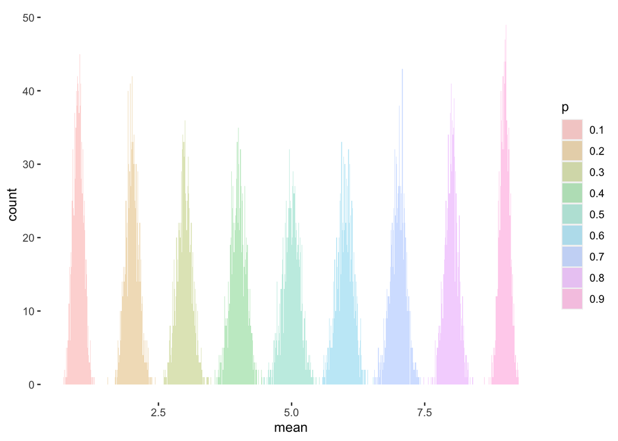

```r
M <- 1000
samp_size <- 100 # 1000 see the difference in predicted v observed

test_norm <- map_df(1:M, ~map(seq(.1, .9, by=.1),
                         ~tibble(mean=mean(rbinom(samp_size, 10,  .)),
                                p=toString(.))))

(ggplot(test_norm) +
    geom_histogram(aes(x=mean, fill=p), alpha=.3, binwidth = .01) +
    theme(panel.background = element_blank())
)
```

```r
(test_norm %>%
    group_by(p) %>%
    summarise(samp_mean=mean(mean),
              samp_sd=sd(mean)) %>%
    mutate(t_var = 10*parse_number(p)*(1-parse_number(p))/sqrt(samp_size))
  )
```

```
## # A tibble: 9 x 4
##   p     samp_mean samp_sd  t_var
##   <chr>     <dbl>   <dbl>  <dbl>
## 1 0.1       0.996  0.0966 0.09
## 2 0.2       2.01   0.124  0.16
## 3 0.3       2.99   0.141  0.210
## 4 0.4       4.00   0.147  0.24
## 5 0.5       4.99   0.162  0.25
## 6 0.6       6.00   0.156  0.24
## 7 0.7       7.00   0.144  0.21
## 8 0.8       8.00   0.126  0.160
## 9 0.9       9.00   0.0934 0.0900
```

Ejercicio 2.10.b

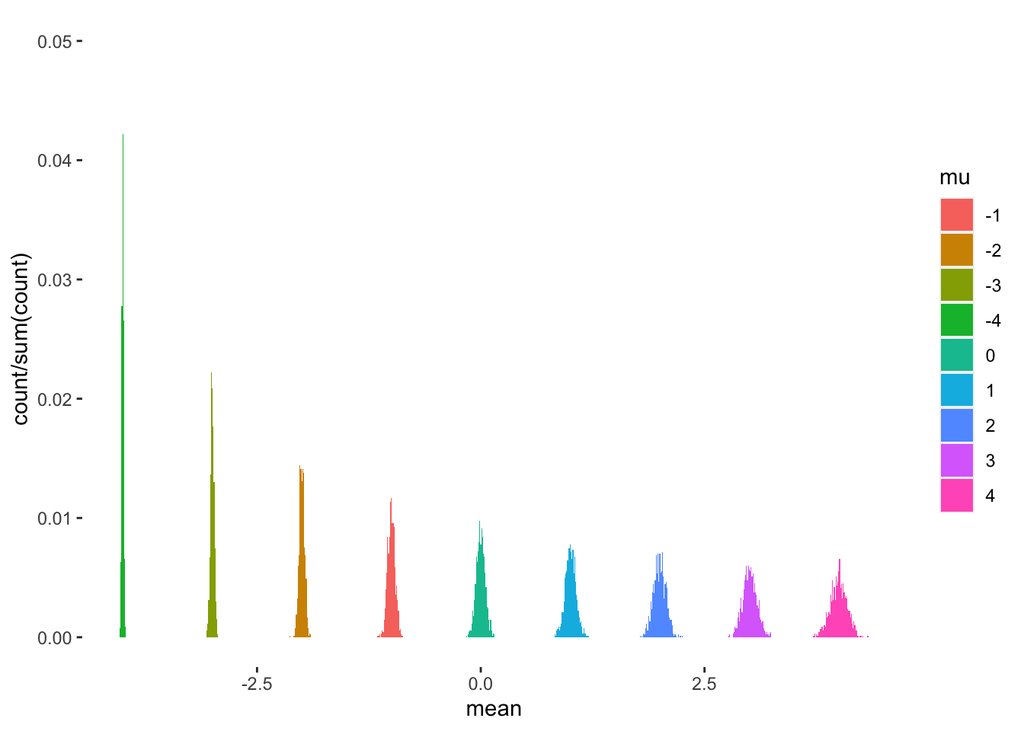

```r
create_sample_dist <- function(params){
  map_df(1:M, ~map2(params[[1]], params[[2]],
                   ~tibble(mean=mean(rnorm(samp_size, .x,  .y)),
                           mu=toString(.x),
                           sd=toString(.y))))
}

test_norm <- create_sample_dist(list(mu=seq(-4, 4, by=1),
                                     sd=seq(.1, .9, by=.1)))

# Change to prop?
# concentration matters!
(ggplot(test_norm) +
    geom_histogram(aes(x = mean, fill=mu, y=..count../sum(..count..)), binwidth = .01) +
    theme(panel.background = element_blank()) + ylim(0, .05)
)
```

### Intervalos de confianza

Ejercicio 2.10.c

Toma 1,000 muestras de tamaño 100 de cada una de las variables numéricas de `diamonds`. Genera la distribución de medias y estandarizala.

1. Haz un histograma para cada distribución de medias.
2. Haz un qqplot para distribución de medias. (HINT: usar multiplot)

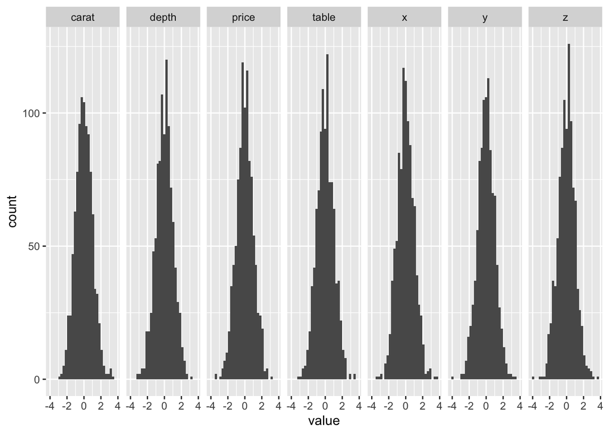

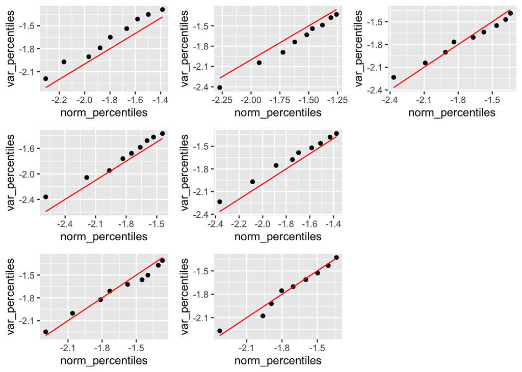

Ejercicio 2.10.d

1. Determina que porcentaje de los intervalos contienen el parámetro poblacional.
2. Genera una gráfica con dichos intervalos.
3. Que pasa si disminuyes el tamaño de la muestra
4. Intenta con una distribución t.

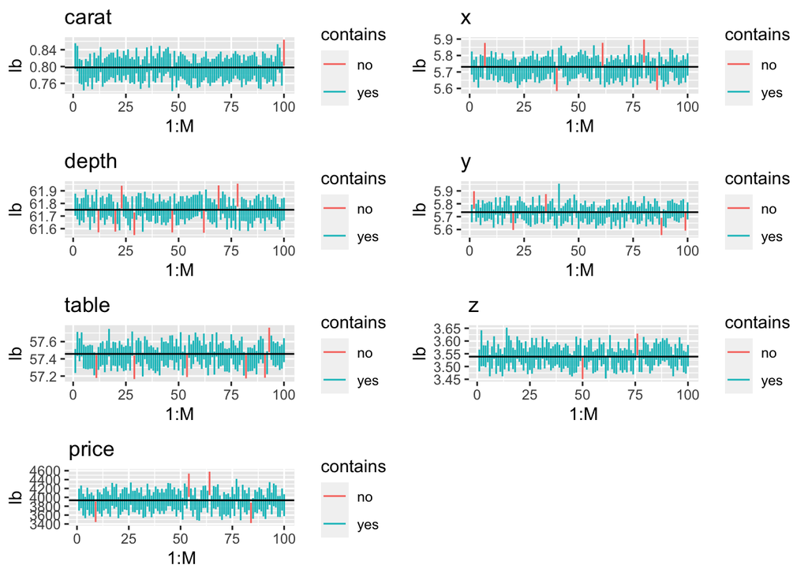

### Pruebas de hipótesis

Genera dos muestras de tamaño 34. Proviniendo de dos poblaciones. P1= rnorm(34, 95, 20) P2= rnorm(34, 75, 13.3)

Supongamos que son las calificaciones promedio en una prueba para alumnos que tomaron café antes de ir a clases y alumnos que no lo hicieron. Queremos generalizar los resultados para toda la población de alumnos.

1. Visualiza las distribuciones

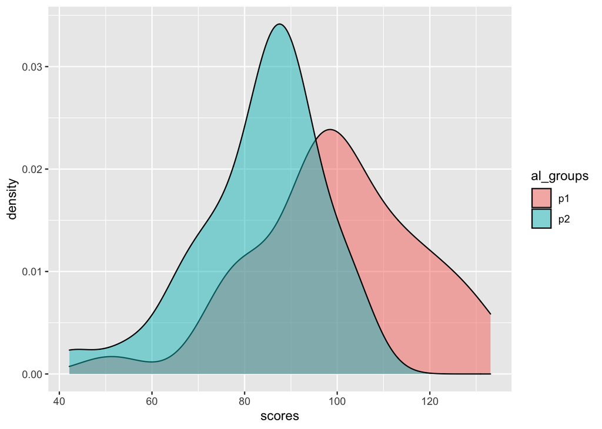

En este caso, nuestra hipótesis nula es que no existe diferencia entre ambas medias, es decir $H_0: \mu_1 = \mu_2$ en donde $\mu_1, \mu_2$ son la media poblacional. La hipótesis nula implica que no hay diferencia estadística en las notas promedio de la población de alumnos que consume y no consume café (recuerda que las pruebas de hipótesis son sobre parámetros poblacionales, ya que los estadísticos en las muestras los podemos calcular directamente). Nuestro estadístico de prueba es entonces $\frac{\bar{\theta}-\theta_{H_0}}{SE_\theta}=\frac{(\bar{x}_1-\bar{x}_2)-0}{\sqrt{\frac{sd_1^2}{n_1} + \frac{sd_2^2}{n_2}}}$

2. Cual es la probabilidad de obtener este valor para nuestro estadísitico si nuestra hipótesis nula fuera que no hay diferencias entre las medias. HINT sd = sqrt(sd1^2/n1 + sd2^2/n2). Usa una distribución T de student con grados de libertad =min(n1-1,n2-1)

```
## [1] 0.0001233726
```

2. Genera un intervalo de 95% de confianza usando la distribución adecuada para el estadístico de prueba.

```
## # A tibble: 1 x 2
##      lb    ub
##   <dbl> <dbl>
## 1  8.97  24.7
```

Notemos que el intervalo de confianza no contiene al cero, lo cual es congruente con el resultado de nuestra prueba de hipótesis.

3. Imagina que las medias son 95 y 85 repite el experimento. luego incrementa el tamaño de muestra a 10,000 observaciones. ¿Qué sucede?

Esto nos da un indicativo de los posibles problemas asociados a los valores p en las pruebas de hipótesis:

- Sesgo de confirmación: si se realiza un experimento un gran número de veces, es posible que alguno de los resultados sea significativo. Pero esto se debe exclusivamente a la variabilidad asociada a la prueba.
- Si la muestra es muy grande, esto hará que diferencias insignificantes en tamaño, sean estadísticamente significativas. Esto nos muestra que este tipo de pruebas no son buenas para determinar efectos de tamaño.
- El poder de la prueba es la capacidad de esta para capturar diferencias estadísticas cuando existen diferencias reales.

#### Bootstrap

Podemos usar la misma lógica que antes, para cualquier estadístico. Se pueden generar muestras con reemplazo a partir de nuestra muestra inicial y calcular intervalos de confianza como hemos hecho hasta ahora.

Ejercicio 2.11

Genera una muestra de 1000 observaciones de la variable precio en el dataset `diamonds`.

1. Con el método bootstrap calcula un intervalo de 95% de confianza para el percentil 75 usando 50 muestras del mismo tamaño que la muestra original.
2. Grafica la distribución de los estadísticos bootstrap.
3. Genera 100 muestras de tamaño de la población original y construye un intervalo de confianza bootstrap de 95%:

$$\hat{\theta}\pm t*SE_{boots}$$
En donde $\hat{\theta}$ es el parámetro estimado con la primera muestra y $SE_{boots}$ es la desviación estándar de su distribución bootstrap de dicha muestra.

¿Qué porcentaje contienen al parámetro poblacional?

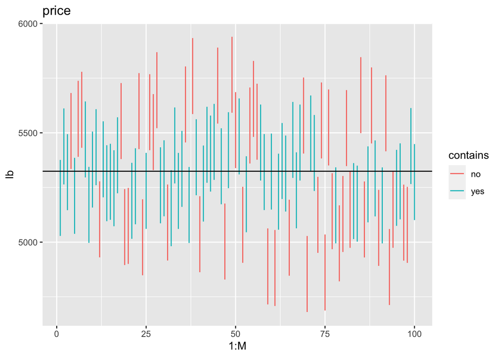

Cómo se puede intuir, esta técnica tiene una gran versatilidad ya que se pueden generar muestras bootstrap para cualquier estadístico. Supongamos que queremos explorar una relación lineal entre ‘price’ y ‘carat’ en el dataset diamonds. De tal forma que $price = \beta_0 + \beta_1*carat$.

Replica la metodología bootstra usando una muestra de tamaño 1,000 y 100 muestras bootstrap. Obten un intervalo bootstrap de 95% de confianza para $\beta_0$ y $\beta_1$. HINT: `model = lm(price ~ carat, data=diamonds)`.